# Introduction

## Plan

- "Classical" RSMs, but only as a jumping-off point.
- The interplay between mathematical models, numerical approximation, simulation, computer experiments, and (field) data.
- Gaussian process (GP) spatial models, emphasizing
  - surrogate computer modeling,
  - sequential design, Bayesian optimization,
  - calibration,
  - variable selection and sensitivity analysis, and more.
- Uncertainty quantification, where statistics ought to monopolize but sometimes doesn't.
- Machine learning methods:
  - "big-\(n\)" GP solutions (sparsity), non-stationary GP modeling, the frontier …

## "Classical" RSM overview

## RSM

**Response surface methodology (RSM)** is a collection of statistical and mathematical techniques for developing, improving, and optimizing processes.

Applications historically come from industry and manufacturing, focused on

- design, development, and formulation of new products,
- and the improvement of existing products,

but also from (national) laboratory research, and with obvious military application.

The over-arching theme is a study of how

- **input variables** controlling a product or process potentially influence a
- **response** measuring performance or quality characteristics.

## Where does the terminology come from?

From visualizing the response plotted as a surface above the the input plane.

- E.g., yield response (\(y\)) in a chemical process via inputs reaction time (\(\xi_1\)) and reaction temperature (\(\xi_2\)).

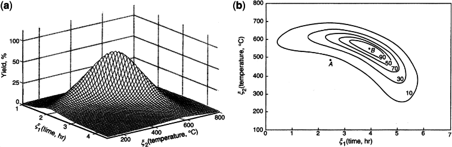

Yield is easily optimized by inspection: \((\xi_1,\xi_2)=(4\;\mathrm{hr},525^\circ\mathrm{C})\).

- Unfortunately, in practice the true response surface is unknown.

## That's where stats comes in

RSMs consists of the experimental strategies for

- exploring the space of the process (i.e., independent) variables (here \(\xi_1\) and \(\xi_2\)) through designed experiments;
- empirical statistical modeling to develop an appropriate approximating relationship between the response (yield) and process variables;
- and optimization/sequential design methods for finding the levels or values of the process variables that produce desirable values of the responses
  - (e.g., that maximize yield or explain variation).

The setup:

- Fit an **empirical model** (usually first or second-order linear) to observed data from the process or system *nearby the current regime* using a carefully designed experiment.
- Gradients and Hessians of the predictive equations yield the method of **steepest ascent** and **ridge analysis**.

## Laborious process

It is a very "careful" enterprise.

- It requires statistical and design expertise, making automation difficult.
- And is at best informal about how to leverage domain specific (physical) knowledge.

These days folks rarely study industrial or physical processes solely via "on-the-bench"/field experiments.

- They are getting more more out of their statistical models, designs and optimizations, by coupling with **mathematical models** of the system(s) they are studying.

Often mathematical models are all there is.

- It can be too expensive or even unethical to gather data on certain phenomena.

## Mathematical models

Gone are the days where simple equations are regarded as sufficient to describe real-world systems.

- Physicists figured that out fifty years ago; industrial engineers followed suit.
- Biologists, social scientists, climate scientists, are coming on board.

Systems of equations are required, often solved over meshes

- e.g., a so-called **finite-element** analysis.

And that's if you're lucky; you might have a big agent/individual-based model that governs how

- predictor and prey (randomly) interact with each other and their habitat;
- an epidemic spreads through a population, person by person;
- citizens make choices about health care and insurance.

## Computer experiments

From [Wikipedia](https://en.wikipedia.org/wiki/Computer_simulation#Computer_simulation_in_science).

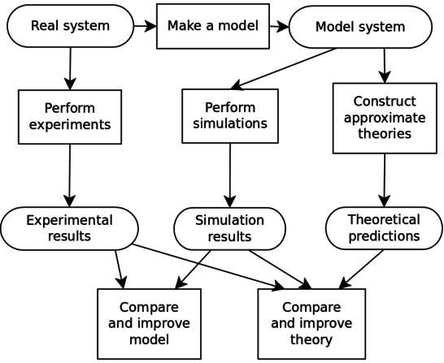

## Cheaper experimentation

Mathematical/computer models allow a cheaper means of

- exploring a system before embarking on a field experiment, or before the next one;
- screening variables and assessing main effects/sensitivity;
- optimizing (maximizing yield, say) or otherwise searching the input space in an automated way (with a wrapper around the simulation code).

And they can be studied in isolation, or coupled with field data experiments:

- tuning or calibrating the computer model, and/or
- leveraging the computer model to predict what would be observed in the field.

## An aircraft wing weight example

The following equation has been used to help understand the weight of an unpainted light aircraft wing as a function of design and operational parameters.

- It is not really a computer simulation, but it will stand in for one in this example.
- It was derived by "calibrating" known physical relationships to curves obtained from existing aircraft data.

The next slide shows

- reasonable ranges for these **natural variables**,
- and a baseline setting coming from a Sessna C172 Skyhawk aircraft.

[output not shown]

## Computer code

```r
wingwt <- function(Sw=0.48, Wfw=0.28, A=0.38, L=0.5, q=0.62, l=0.344, Rtc=0.4,
    Nz=0.37, Wdg=0.38)
  {
    ## put coded inputs back on natural scale
    Sw <- Sw*(200 - 150) + 150
    Wfw <- Wfw*(300 - 220) + 220
    A <- A*(10 - 6) + 6
    L <- (L*(10 - (-10)) - 10) * pi/180
    q <- q*(45 - 16) + 16
    l <- l*(1 - 0.5) + 0.5
    Rtc <- Rtc*(0.18 - 0.08) + 0.08
    Nz <- Nz*(6-2.5) + 2.5
    Wdg <- Wdg*(2500 - 1700) + 1700

    ## calculation on natural scale
    W <- 0.036*Sw^0.758 * Wfw^0.0035 * (A/cos(L)^2)^0.6 * q^0.006
    W <- W * l^0.04 * (100*Rtc/cos(L))^(-0.3) * (Nz*Wdg)^(0.49)
    return(W)
  }
```

## Sensitivity analysis

Now, if computing is cheap we can explore which variables matter and which work together.

Lets make a 2d grid for exploring pairs of inputs.

```r
x <- seq(0,1,length=100)
g <- expand.grid(x,x)
```

Now we can use the grid to, say, vary \(N_{\mathrm z}\) and \(A\), with the others fixed at their baseline values.

```r
W.A.Nz <- wingwt(A=g[,1], Nz=g[,2])
```

(Some auxiliary code for plotting images with smooth colors.)

```r
cs <- heat.colors(128)
bs <- seq(min(W.A.Nz), max(W.A.Nz), length=129)
```

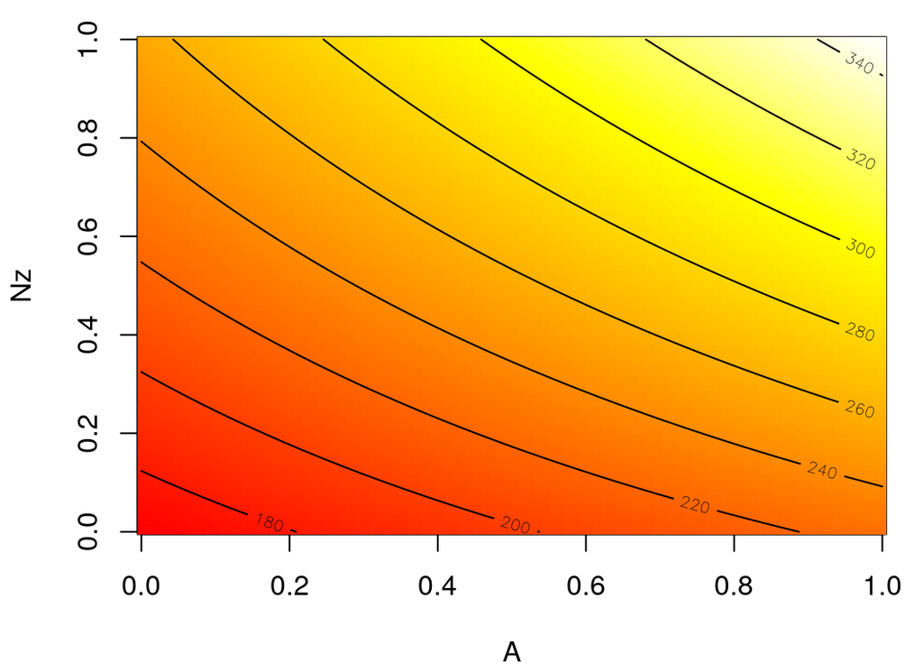

```r
image(x,x, matrix(W.A.Nz, ncol=length(x)), col=cs,breaks=bs,xlab="A",ylab="Nz")
contour(x,x, matrix(W.A.Nz, ncol=length(x)), add=TRUE)
```

- Indicates a heavy wing for high aspect ratios (\(A\)) and large \(g\)-forces (large \(N_{\mathrm z}\)).

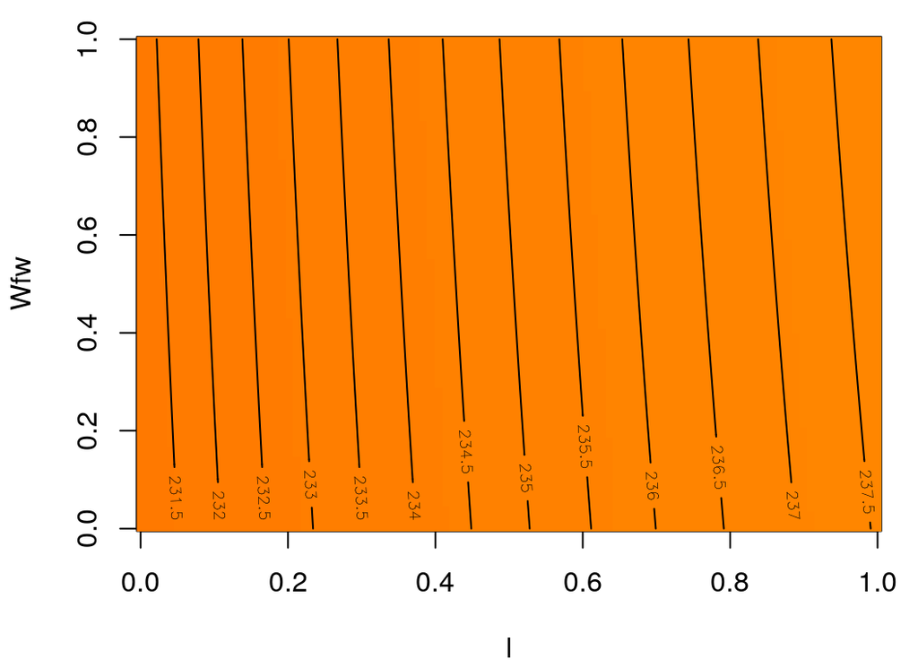

```r
W.l.Wfw <- wingwt(l=g[,1], Wfw=g[,2])
image(x,x, matrix(W.l.Wfw,ncol=length(x)), col=cs,breaks=bs,xlab="l",ylab="Wfw")
contour(x,x, matrix(W.l.Wfw,ncol=length(x)), add=TRUE)
```

- no interaction and very small effect compared to \(A\) and \(N_{\mathrm z}\)

## Sensible but expensive

Well that's all fine and good. We've learned about two pairs of inputs (out of 36 pairs)

- and for each pair we evaluated `wingwt` 10,000 times.
- So to do all pairs would require 360K evaluations — not a reasonable number with a real computer simulation that takes any non-trivial amount of time to evaluate.
  - Even at just 1s per evaluation we're talking > 100 hours.
  - Many computer experiments take minutes/hours/days to execute a single run.
- And even then, we'd only really know about pairs.
- How about main effects, or three-way interactions?

We need a different strategy.

## Computer model emulation

How about (meta-) modeling the computer model?

The setting is as follows.

- The computer model \(f(x): \Re^p \rightarrow \Re\) is expensive to evaluate.
- So we evaluate it at a "small", well-chosen design of locations \(X_n = \{x_1, \dots, x_n\}\), obtaining \(n\) pairs \((x_i, y_i)\), where \(y_i \sim f(x_i)\) for \(i=1,\dots, n\).
  - If \(f\) is deterministic then \(y_i = f(x_i)\).
- The \(n\) data pairs \(D_n = (X_n, Y_n)\) are used to train a statistical (regression) model, producing an **emulator** \(\hat{f}_n\).
- A good emulator does about what \(f\) would do.

## Surrogate model

A good emulator

- provides a predictive distribution \(\hat{f}_n(x)\)
  - whose mean can be used as a **surrogate** for \(f(x)\) at new \(x\)-locations
  - and whose variance provides uncertainty estimates — intervals for \(f(x)\) that have good coverage properties;
- may interpolate when the computer model \(f\) is deterministic;
- and can be used in any way \(f\) could have been used, qualified with appropriate **uncertainty quantification**.

Perhaps most importantly, fitting \(\hat{f}_n\) and making predictions \(\hat{f}_n(x)\) should be much faster than working directly with \(f\).

## Space-filling design

Just like in classical RSMs, choosing the design \(X_n\) is crucial to good performance.

It might be tempting to work on a grid.

- But that won't work in our 9-dimensional exercise.
- Even just having a modest ten grid elements per dimension would balloon into \(10^9 \equiv\) 1-billion runs of the computer code!

So-called **space-filling** designs were created to mimic the spread of grids, while sacrificing their regularity in order to dramatically reduce their size.

## Latin hypercubes

One easy such space-filling design is called a **Latin hypercube sample** or LHS.

- It is better than a (uniform) random sample (say via `runif` in R) because it is less clumpy, guaranteeing uniformity in marginal samples.
- But it is not as spread out as a so-called **maxmin** design
  - which maximizes the minimum distance between design elements \(x_i\).

Lets generate a 9d LHS …

```r
library(lhs)
n <- 1000
X <- data.frame(randomLHS(n, 9))
names(X) <- names(formals(wingwt))
```

… then evaluate `wingwt` at those locations.

```r
Y <- wingwt(X[,1], X[,2], X[,3], X[,4], X[,5], X[,6], X[,7], X[,8], X[,9])
```

## Linear model emulation

Ok now, what do we do with that?

- An emulator could be useful for visualization.

How about a `step`-wise selected **first-order model with interactions**?

```r
fitlm <- lm(log(Y)~.^2, data=data.frame(Y,X))
fitstep <- step(fitlm, scope=formula(fitlm), direction="backward", trace=0)
coef(fitstep)[-1]
```

```
##            Sw           Wfw             A             L             q
##  0.2151964663 -0.0174715530  0.3037097390  0.0001099775 -0.0075829227
##             l           Rtc            Nz           Wdg         Wfw:L
##  0.0188404770 -0.2437040119  0.4295539016  0.1818892666  0.0126040980
##         Wfw:q           A:l          A:Nz           L:q           q:l
##  0.0236520585  0.0099250927 -0.0125569245 -0.0124328731  0.0127520557
##          l:Nz       Rtc:Wdg
## -0.0099469172  0.0112509711
```

- Least squares doesn't leverage the "low" noise (deterministic) simulations.
- And the relationship is likely nonlinear.

## Gaussian process emulation

We learned something with the linear model,

- but we shouldn't expect it to yield good predictions.

Gaussian processes (GPs) are a generalization of linear models

- but non-linear, and offer more control over signal vs noise

```r
library(laGP)
fit.gp <- newGPsep(X, Y, 2, 1e-6, dK=TRUE)
mle <- mleGPsep(fit.gp)
baseline <- matrix(rep(as.numeric(formals(wingwt)), nrow(g)), ncol=9, byrow=TRUE)
XX <- data.frame(baseline)
names(XX) <- names(X)
XX$A <- g[,1]
XX$Nz <- g[,2]
p <- predGPsep(fit.gp, XX, lite=TRUE)
```

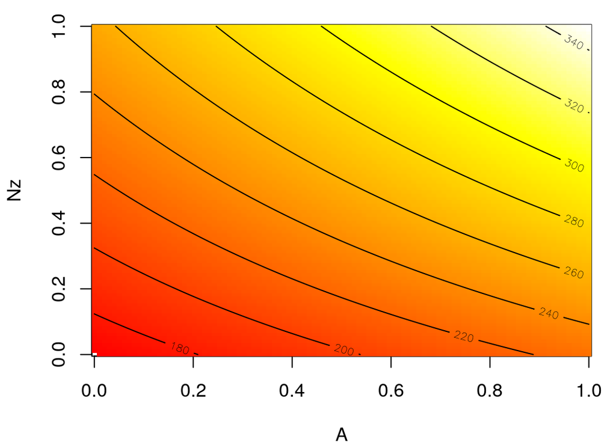

```r
image(x, x, matrix(p$mean, ncol=length(x)), col=cs, breaks=bs, xlab="A", ylab="Nz")
contour(x, x, matrix(p$mean, ncol=length(x)), add=TRUE)
```

- Kind of amazing that 1K evaluations in 9d can do the work of 10K in 2d!

## What else?

We can use the emulator, via `predGPsep` in this case, to do whatever `wingwt` could do!

How about main effects?

```r
meq1 <- meq2 <- me <- matrix(NA, nrow=length(x), ncol=ncol(X))
for(i in 1:ncol(me)) {
    XX <- data.frame(baseline)[1:length(x),]
    XX[,i] <- x
    p <- predGPsep(fit.gp, XX, lite=TRUE)
    me[,i] <- p$mean
    meq1[,i] <- qt(0.05, p$df)*sqrt(p$s2) + p$mean
    meq2[,i] <- qt(0.95, p$df)*sqrt(p$s2) + p$mean
}
```

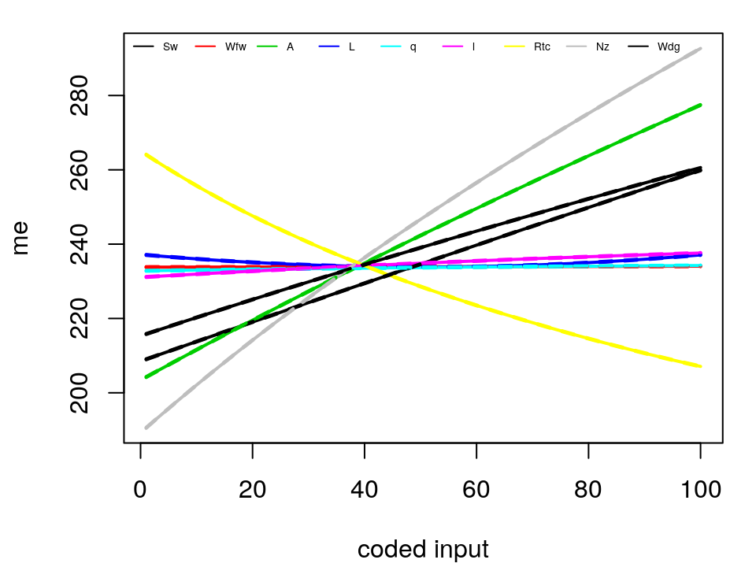

```r
matplot(me, type="l", lwd=2, lty=1, col=1:9, xlab="coded input")
matlines(meq1, type="l", lwd=2, lty=2, col=1:9)
matlines(meq2, type="l", lwd=2, lty=2, col=1:9)
legend("topleft", names(X), lty=1, col=1:9, horiz=TRUE, bty="n", cex=0.43)
```

- \(W_{\mathrm{fw}}\), \(\Lambda\), \(q\), and \(\lambda\) barely matter!

## GP emulation is super powerful

Lots more to come.

- GPs have revolutionized machine learning, spatial statistics ("kriging"), and computer simulation experiments.

But they are no panacea.

- They can be **slow** because they involve big matrix decompositions.
- They can over-smooth things,
- and even though they are super flexible they can sometimes be too **rigid**.

The rest of this slide deck sets the stage by introducing four motivating examples where

- there is limited (or no) field data on complicated physical processes,
- and we have computationally expensive computer model simulations.

## Rocket Booster Dynamics

## Langley glide-back booster (LGBB)

NASA proposed a re-usable rocket booster. They developed a CDF solver, **Cart3D**, to simulate dynamics as the rocket re-enters the atmosphere.

- 3 **inputs** describe configuration at re-entry:
- 6 **outputs** delivered in 5+ hours.

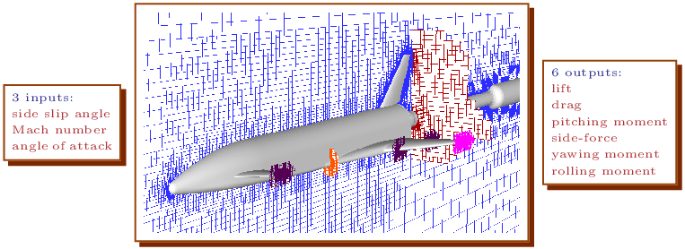

## LGBB data

There are several historical versions of the data.

- The first, oldest, version of the data involves
  - a less reliable code implementing the solver
  - evaluated on **hand-designed input grids**.

```r
lgbb1 <- read.table("lgbb/lgbb_original.txt", header=TRUE)
names(lgbb1)
```

```
## [1] "mach"  "alpha" "beta"  "lift"  "drag"  "pitch" "side"  "yaw"   "roll"
```

```r
nrow(lgbb1)
```

```
## [1] 3167
```

- The grids double up effort in interesting regions, e.g., near the sound barrier.

Lift response indicates some numerical instabilities.

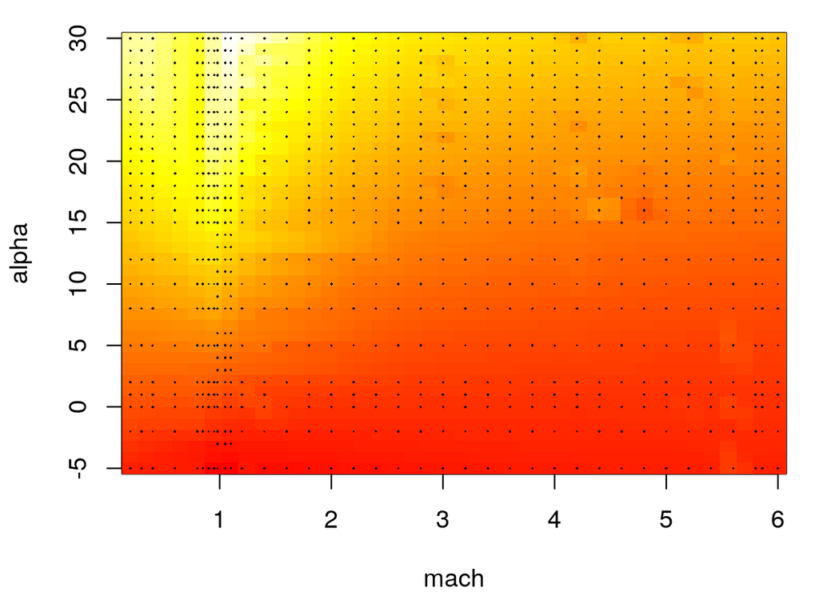

```r
library(akima)
g <- interp(lgbb1$mach, lgbb1$alpha, lgbb1$lift, dupl="mean")
image(g, col=heat.colors(128), xlab="mach", ylab="alpha")
points(lgbb1$mach, lgbb1$alpha, cex=0.25, pch=18)
```

Grids have drawbacks. The data has 3167 rows, but there are only 37 and 33 unique mach and alpha values, respectively.

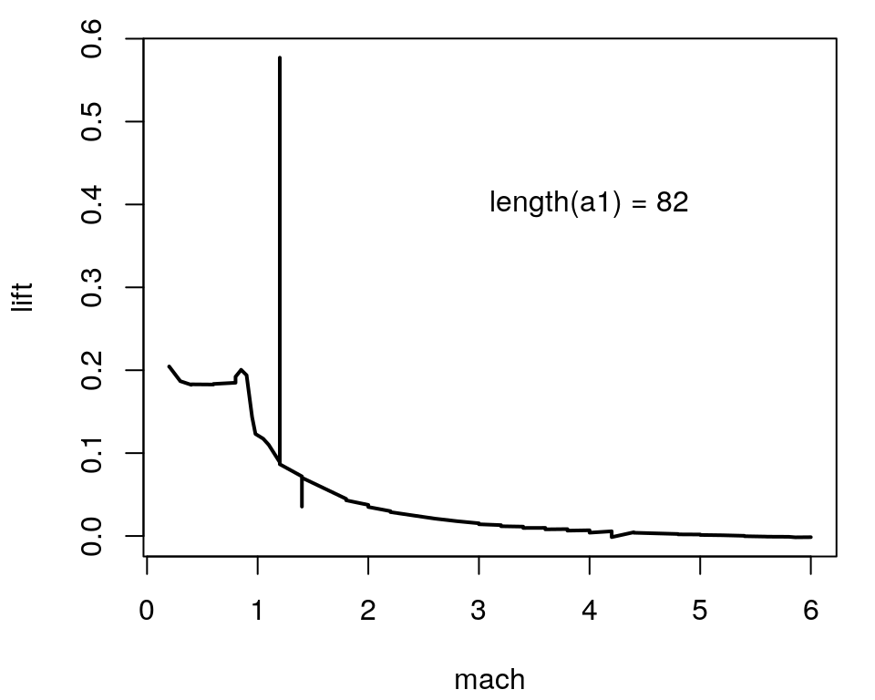

```r
a1 <- which(lgbb1$alpha == 1); a1 <- a1[order(lgbb1$mach[a1])]
plot(lgbb1$mach[a1], lgbb1$lift[a1], type="l", xlab="mach", ylab="lift", lwd=2)
text(4, 0.4, paste("length(a1) =", length(a1)))
```

**Cart3D.v2** was more stable; and run on an **fully automated adaptive grid** of just 780 points.

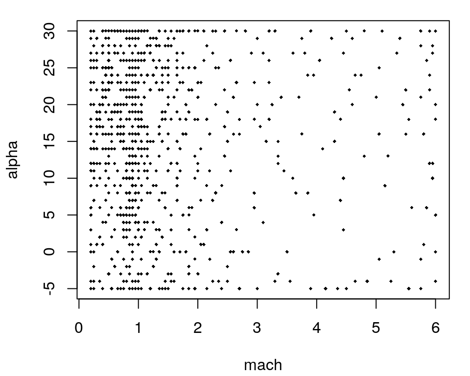

```r
lgbb2 <- read.table("lgbb/lgbb_as.txt", header=TRUE)
plot(lgbb2$mach, lgbb2$alpha, xlab="mach", ylab="alpha", pch=18, cex=0.5)
```

Slices have lower resolution, …

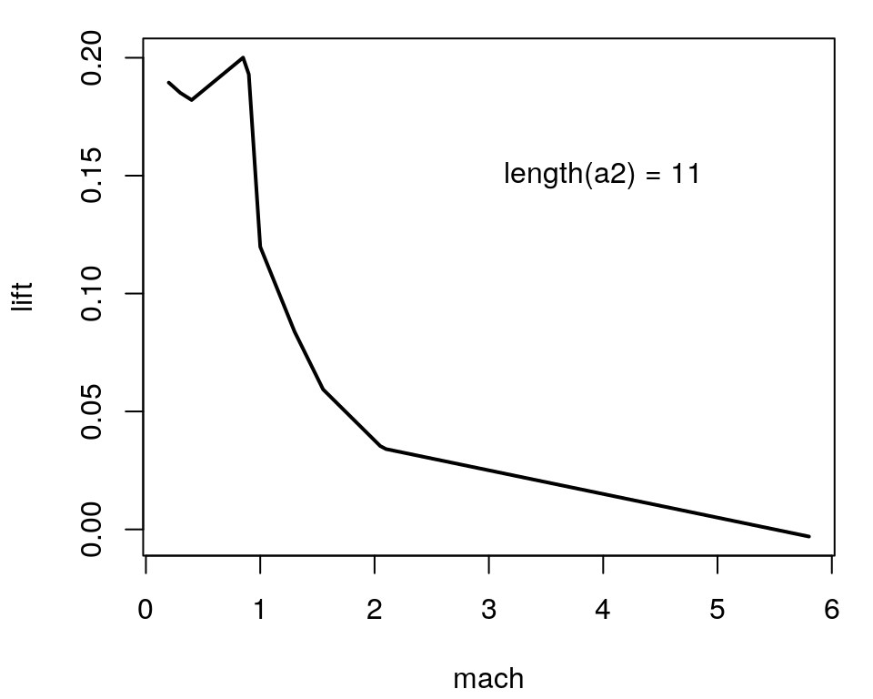

```r
a2 <- which(lgbb2$alpha == 1); a2 <- a2[order(lgbb2$mach[a2])]
plot(lgbb2$mach[a2], lgbb2$lift[a2], type="l", xlab="mach", ylab="lift", lwd=2)
text(4, 0.15, paste("length(a2) =", length(a2)))
```

… but GP emulators can fill in the gaps (suspend disbelief for now).

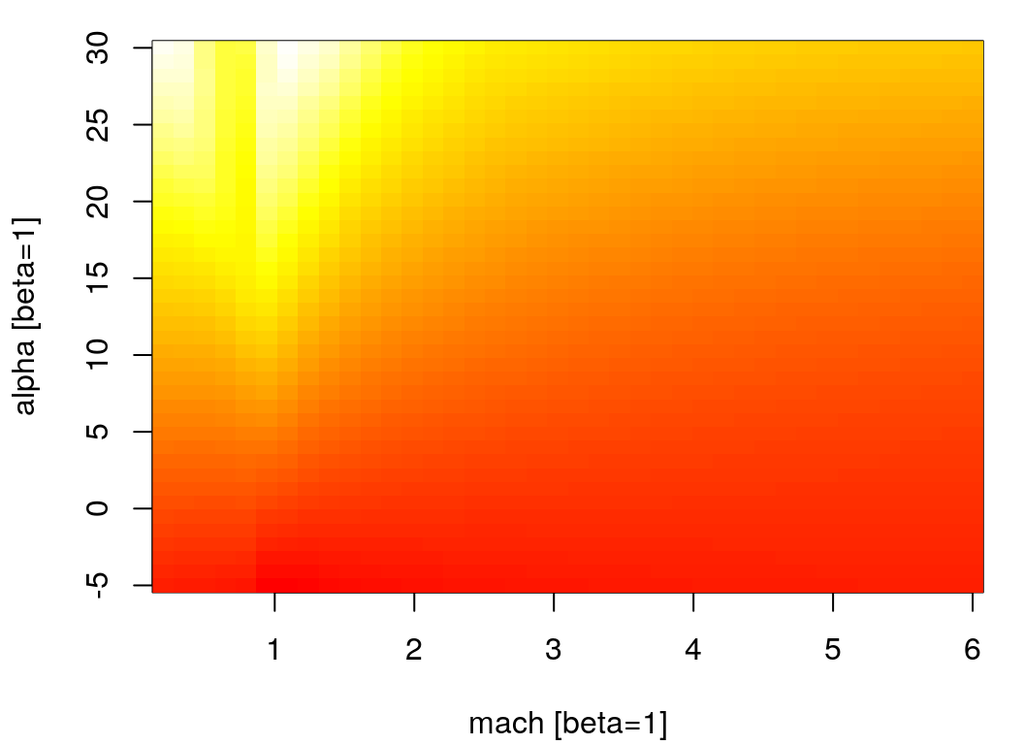

```r
load("lgbb/lgbb_fill.RData")
lgbb.b1 <- lgbb.fill[lgbb.fill$beta == 1, ]
g <- interp(lgbb.b1$mach, lgbb.b1$alpha, lgbb.b1$lift)
image(g, col=heat.colors(128), xlab="mach [beta=1]", ylab="alpha [beta=1]")
```

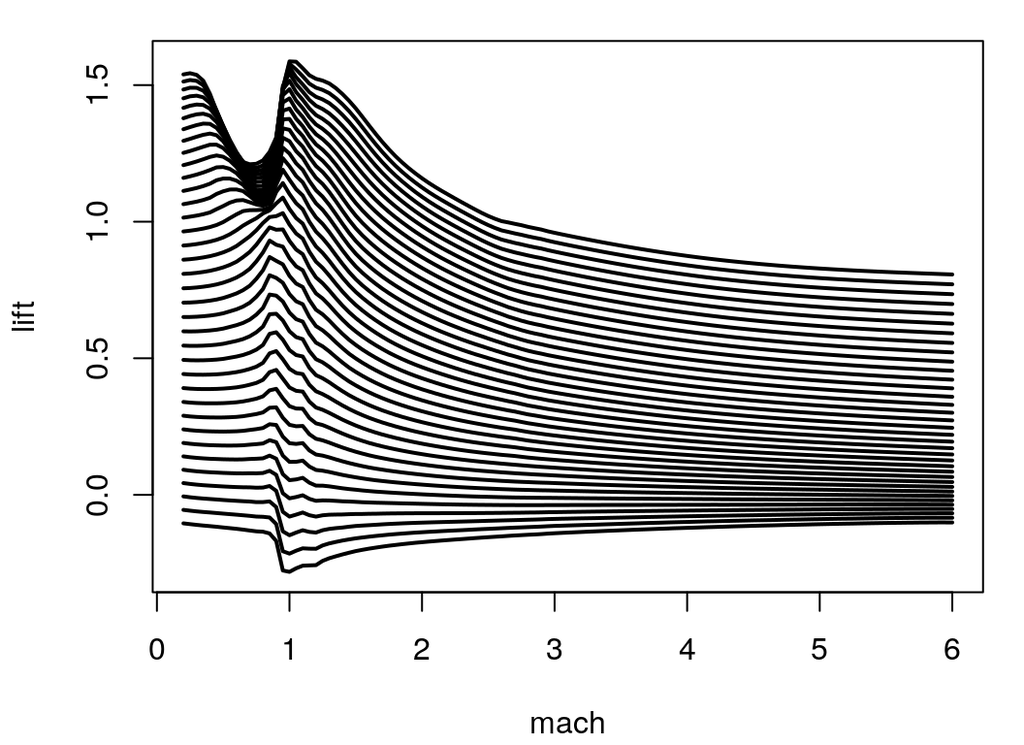

```r
plot(lgbb.b1$mach, lgbb.b1$lift, type="n", xlab="mach", ylab="lift")
for(ub in unique(lgbb.b1$alpha)) {
  a <- which(lgbb.b1$alpha == ub)
  a <- a[order(lgbb.b1$mach[a])]
  lines(lgbb.b1$mach[a], lgbb.b1$lift[a], type="l", lwd=2)
}
```

## Radiative Shock Hydrodynamics

## CRASH

Radiative shocks arise from astrophysical phenomena (e.g., super-novae) and other high temperature systems.

- These are shocks where radiation from the shocked matter dominates the energy transport, and results in a complex evolutionary structure.

The University of Michigan's **C**enter for **Ra**diative **S**hock **H**ydrodynamics (**CRASH**) is tasked with modeling a particular high-energy laser radiative shock system.

They have

- collected a small amount data from a limited field experiment
- and developed a mathematical model (and computer implementation) that simulates the field apparatus.

## Radiative shock experiment

A high-energy laser irradiates a Be disk at the front of a Xe-filled tube, launching a shock.

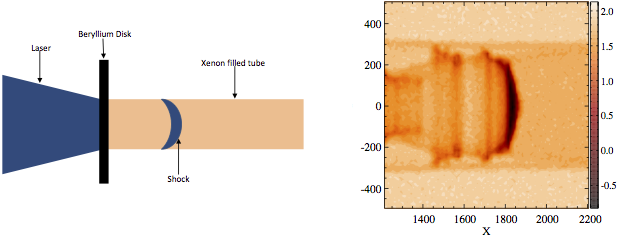

Experiments involve:

- **9 design variables**: describing energy, disk, tube
- **response**: distance the wave travels in a certain time

| Design Parameter | CE1 | CE2 | Field Design |
| --- | --- | --- | --- |
| Be thick (microns) | [18,22] | 21 | 21 |
| Xe fill press (atm) | [1.100,1.2032] | [0.852,1.46] | [1.032,1.311] |
| Time (nano-secs) | [5,27] | [5.5,27] | 6-values in [13, 28] |
| Tube diam (microns) | 575 | [575,1150] | {575, 1150} |
| Taper len (microns) | 500 | [460,540] | 500 |
| Nozzle len (microns) | 500 | [400,600] | 500 |
| Aspect ratio (microns) | 1 | [1,2] | 1 |
| Laser energy (J) | [3600,3990] |  | [3750.0 3889.6] |
| Eff laser energy (J) |  | [2156.4,4060] |  |

In addition, there are two parameters which pertain only to the computer model

- so-called **calibration** or **tuning** parameters.

| Calibration parameter | CE1 | CE2 | Field Design |
| --- | --- | --- | --- |
| Electron flux limiter | [0.04, 0.10] | 0.06 |  |
| Energy scale-factor | [0.40,1.10] | [0.60,1.00] |  |

The relationship between design variables and output was explored via

- a **field experiment** with 20 observations
- and **two computer experiments**, 2618 and 2384 runs respectively.

Interest lies in combining the two data sources to learn about radiative shock hydrodynamics.

- This requires calibrating the computer model to the field data.

In the 20 **field data** "runs", only four variables (besides `ShockLocation`) are varied.

```r
crash <- read.csv("crash/CRASHExpt_clean.csv")
crash$BeThinkness <- 21  ## Not recorded in field data
print(u <- apply(crash, 2, function(x) { length(unique(x)) }))
```

```
##   LaserEnergy   GasPressure   AspectRatio  NozzleLength   TaperLength
##            13            11             1             1             1
##  TubeDiameter          Time ShockLocation   BeThinkness
##             2             6            20             1
```

A linear model indicates that only **time** has a substantial **main effect**.

```r
fit <- lm(ShockLocation ~., data=crash[,u > 1])
summary(fit)$coefficients[-1,]
```

```
##                   Estimate   Std. Error     t value     Pr(>|t|)
## LaserEnergy  -3.968075e-01 1.491184e+00 -0.26610235 7.937833e-01
## GasPressure  -1.970699e+02 8.476603e+02 -0.23248692 8.193021e-01
## TubeDiameter -3.423611e-02 4.068208e-01 -0.08415528 9.340459e-01
## Time          1.040318e+11 1.566597e+10  6.64062240 7.866793e-06
```

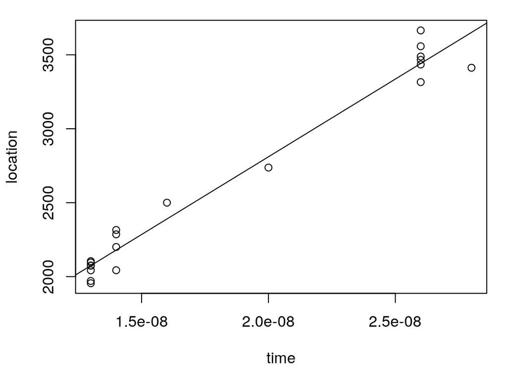

```r
fit.time <- lm(ShockLocation ~ Time, data=crash)
plot(crash$Time, crash$ShockLocation, xlab="time", ylab="location")
abline(fit.time)
```

- Time mops up all of the variability in this data with \(R^2 =\) 0.9718531.

## Computer model data

Experiment CE1 varied all but four of the parameters.

```r
ce1 <- read.csv("crash/RS12_SLwithUnnormalizedInputs.csv")
ce1 <- ce1[,-1] ## first col is FileNumber
u.ce1 <- apply(ce1, 2, function(x) { length(unique(x)) })
fit.ce1 <- lm(ShockLocation ~., data=ce1[,u.ce1 > 1])
summary(fit.ce1)$coefficients
```

```
##                          Estimate   Std. Error    t value      Pr(>|t|)
## (Intercept)         -4.601356e+02 1.320949e+02  -3.483372  5.032847e-04
## BeThickness         -7.594590e+01 2.103686e+00 -36.101350 7.283200e-232
## LaserEnergy          3.152568e-01 2.148655e-02  14.672282  6.782470e-47
## GasPressure         -3.829176e+02 8.129088e+01  -4.710461  2.600980e-06
## Time                 1.343696e+11 4.998054e+08 268.843861  0.000000e+00
## ElectronFluxLimiter  4.125576e+02 1.399752e+02   2.947363  3.233373e-03
## EnergyScaleFactor    1.775947e+03 1.214335e+01 146.248499  0.000000e+00
```

- CE1 linear model fit indicates more nuanced relationship (CE2 is similar).

## Energy and time work together

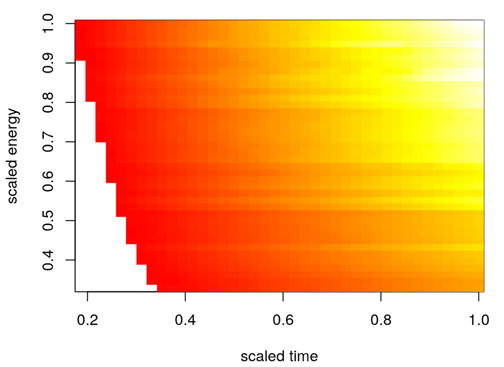

```r
x <- ce1$Time; y <- ce1$LaserEnergy * ce1$EnergyScaleFactor
g <- interp(x/max(x), y/max(y), ce1$ShockLocation, dupl="mean")
image(g, col=heat.colors(128), xlab="scaled time", ylab="scaled energy")
```

## Computer model calibration

However, there is likely predictability left on the table.

- Physical phenomena rarely covary linearly.

We will see how to combine computer model and field data of this sort

- via **computer model calibration**:
  - (non-linearly) emulating the computer model with GPs;
  - estimating the bias between the computer model and the field data;
  - finding the best setting of the calibration parameters relative to that bias;
  - finally, building a predictor that combines (emulated) computer model predictions with bias predictions.

## Predicting Satellite Drag

## Satellite Orbit prediction

Researchers at Los Alamos National Laboratory (LANL) are tasked with predicting orbits for dozens of research satellites, e.g.:

- **HST** (Hubble space telescope)
- **ISS** (International space station)
- **GRACE** (Gravity Recovery and Climate Experiment)
  - a NASA & German Aerospace Center collaboration
- **CHAMP** (Challenging Minisatellite Payload)
  - German satellite for atmospheric and ionospheric research

Why?

- To plan experiments: what can we see when?
- Adjust course if necessary, for experimental reasons or to **avoid collisions**!

## Drag

An important input into their prediction models is **atmospheric drag**.

Drag depends on

- satellite geometry, orientation, temperature,
- atmospheric chemical composition: concentrations of (O, O\(_2\), N, N\(_2\), He, H);
- which depend on position (latitude and longitude) and altitude.

Numerical simulations

- produce accurate drag coefficient estimates up to uncertainties in atmospheric and gas–surface interaction (GSI) models,
- but are too slow for real-time applications.

## Geometry

Geometry is specified in a so-called "mesh file", an ASCII representation of a picture like this, for the Hubble space telescope.

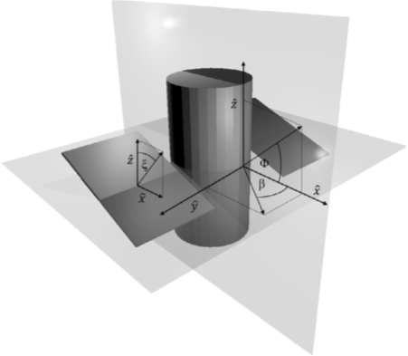

## Position and environmental variables

| Symbol [ascii] | Parameter [units] | Range |
| --- | --- | --- |
| \(v_{\mathrm{rel}}\) [`Umag`] | velocity [m/s] | [5500, 9500] |
| \(T_s\) [`Ts`] | surface temperature [K] | [100, 500] |
| \(T_a\) [`Ta`] | atmospheric temperature [K] | [200, 2000] |
| \(\theta\) [`theta`] | yaw [radians] | [\(-\pi\), \(\pi\)] |
| \(\phi\) [`phi`] | pitch [radians] | [\(-\pi/2\), \(\pi/2\)] |
| \(\alpha_n\) [`alphan`] | normal energy accommodation coefficient [unitless] | [0, 1] |
| \(\sigma_t\) [`sigmat`] | tangential momentum accommodation coefficient [unitless] | [0, 1] |

## Emulation goal

Researchers at LANL wanted GP drag emulation

- such that predictions were within 1% of the "true" outputs based on root mean-squared percentage error (RMSPE).

But they realized that they would need \(N \gg 4\)M runs to accomplish that goal.

- GPs don't scale well to data that big.
- So as proof-of-concept, they limited the range of angles so they could work with a much smaller data set [(Metha et al., 2014)](http://bobby.gramacy.com/teaching/rsm/metha_etal_2014.pdf).

| Symbol [ascii] | Ideal Range | Reduced Range | Percentage |
| --- | --- | --- | --- |
| \(\theta\) [yaw] | \([-\pi, \pi]\) | [-0.052313, 0.052342] | 1.7% |
| \(\phi\) [pitch] | \([-\pi/2, \pi/2]\) | [1.059e-05, 5.232e-02] | 1.7% |

## On the GRACE satellite

Lets look at the GRACE runs (for the He species) that LANL did,

- training on their \(N=1000\)-sized design and
- calculating out-of-sample RMSE on a testing set of size 100

```r
train <- read.csv("lanl/GRACE/CD_GRACE_1000_He.dat", sep=" ", header=FALSE)
test <- read.csv("lanl/GRACE/CD_GRACE_100_He.dat", sep=" ", header=FALSE)
nms <- c("Umag", "Ts", "Ta", "alphan", "sigmat", "theta", "phi", "drag")
names(train) <- names(test) <- nms
print(r <- apply(rbind(train, test)[,-8], 2, range))
```

```
##          Umag       Ts        Ta       alphan       sigmat        theta
## [1,] 5501.933 100.0163  201.2232 0.0008822413 0.0007614135 1.270032e-05
## [2,] 9497.882 499.8410 1999.9990 0.9999078000 0.9997902000 6.978310e-02
##              phi
## [1,] -0.06978125
## [2,]  0.06971254
```

Convert to coded inputs.

```r
X <- train[,1:7]; XX <- test[,1:7]
for(j in 1:ncol(X)) {
    X[,j] <- X[,j] - r[1,j]; XX[,j] <- XX[,j] - r[1,j];
    X[,j] <- X[,j]/(r[2,j]-r[1,j]); XX[,j] <- XX[,j]/(r[2,j]-r[1,j])
}
```

Fit a GP and make predictions

```r
library(laGP)
fit.gp <- newGPsep(X, train[,8], 2, 1e-6, dK=TRUE)
mle <- mleGPsep(fit.gp)
p <- predGPsep(fit.gp, XX, lite=TRUE)
rmspe <- sqrt(mean((100*(p$mean - test[,8])/test[,8])^2))
rmspe
```

```
## [1] 0.7401338
```

- Better than 1%.

## Big runs

Beating 1% on the whole input space will, for starters, require more runs.

Last summer I compiled a new suite of computer model runs for

- HST (\(N=\) 2M) for each species, divided equally between panel angles;
- and GRACE (\(N=\) 1M) – a smaller design is sufficient, but GRACE is slower,

separately for each chemical species.

- Together, these took about 70K CPU core hours.

But if GPs struggle with \(N\approx\) 1K how are we going to deal with \(N=\) 2M?

- We'll have to cut corners somehow.

## Promising results

A soft divide-and-conquer technique called "local approximate GPs" works.

- We'll learn about `laGP` and some other big data GP alternatives.

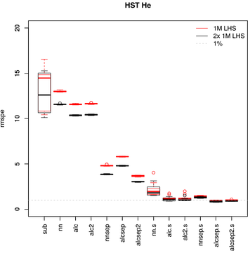

## Groundwater remediation

## Dirty water

Worldwide, there are more than 10,000 contaminated land sites [(Meer et al., 2008)](http://pubs.rsc.org/en/content/chapter/bk9780854042944-00403/978-0-85404-294-4#!divabstract).

- Environmental cleanup at these sites has received increased attention over the past 20-30 years.

Preventing the migration of contaminant plumes is vital to protecting water supplies and preventing disease.

One approach is pump-and-treat remediation, in which wells are strategically placed to

- pump out contaminated water,
- purify it,
- and inject the treated water back into the system to prevent contaminant spread.

## A case study

Consider the 580-acre Lockwood Solvent Groundwater Plume Site, an EPA Superfund site located near Billings Montana.

- As a result of industrial practices, the groundwater at this site is contaminated with volatile organic compounds that are hazardous to human health.
- To prevent further expansion of these plumes, six pump and treat wells have been proposed.

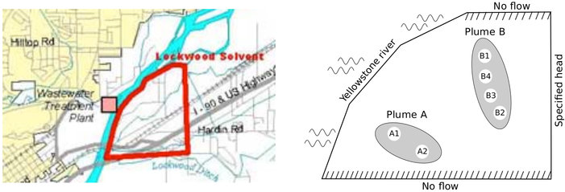

## Computer model and optimization

The amount of contaminant exiting the boundaries of the system (in particular the river) depends on

- the placement of the wells and their pumping rates.

An **analytic element method** groundwater model was developed

- to simulate the amount of contaminant exiting the (2) boundaries under different pumping regimes [(Matott, et al., 2006)](http://www.sciencedirect.com/science/article/pii/S0309170805001922).

[Mayer, et al., (2002)](http://www.sciencedirect.com/science/article/pii/S0309170802000544) first posed the pump-and-treat setting, generically, as a **constrained "blackbox" optimization** problem.

- Fixing the well locations, let \(x_1,\dots, x_6\) denote pumping rates for six wells, consider

\[ \min_{x} \; \left\{f(x) = \sum_{j=1}^6 x_j : c_1(x)\leq 0, \, c_2(x)\leq 0, \, x\in [0, 2\cdot 10^4]^6 \right\}. \]

[Matott, et al., (2011)](http://amstat.tandfonline.com/servlet/linkout?suffix=cit0018&dbid=128&doi=10.1080%2F00401706.2015.1014065&key=000299139800019) compared MATLAB and Python optimizers, treating constraints via the **additive penalty method**, initialized at the known-valid input \(x_j^0 = 10^4\).

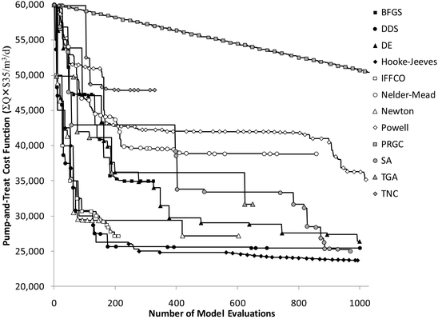

## Objective improving comparator

It is interesting to ask …

- What makes the good methods good?
- Why do the bad methods (in some cases) fail so spectacularly?
- And by the way, how are statistics and RSMs involved?

Consider the following random search method that I call **objective improving candidates**.

Given the current best valid input \(x^*\), i.e.,

- \(c(x^*) \leq 0\), and
- \(f(x^*) = \sum_j x_j^* < f(x)\) for all other (tried so far) \(x\) such that \(c(x) \leq 0\),

draw uniformly from \(\{x : f(x) < f(x^*)\}\), for example via rejection.

Here I've extracted the first 500 iterations from Matott, et al., (2011),

- which are in `runlock/pato_results.csv`,
- and added average progress (best valid value) from 30 repeated runs of OICs.

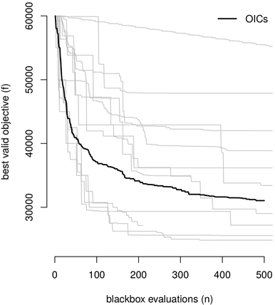

## Sequential design

Half of the MATLAB/Python methods are not doing better (on average) than a slightly modified "random search".

- They are getting stuck in a local minima, and failing to explore other opportunities.

Fitting a surrogate model to blackbox evaluations can allow statistical decision criteria to judge trade-offs between reward and uncertainty;

- in this case, balancing exploration and exploitation.

**Sequential design** is the process of using (surrogate) model fits to drive future data collection, in order to maximize information or reduce variance, say.

- One popular application of this idea to optimization is called **expected improvement (EI)**.
- The machine learning community calls this **Bayesian optimization** owing to the Bayesian interpretation of GP learning.